신록예찬's 블로그

# (노트) Boxplot, Histogram

완성

Sep 5, 2021 • 신록예찬 • 30 min read

파이썬

- import
- boxplot
  - 전북고예제: 평균은 괜찮은 측정값인가? (통계학과)
  - 박스플랏이란? (통계학과)
  - plotly (컴퓨터공학과)
- histogram
  - 히스토그램이란?
  - 전북고예제
  - seaborn
  - plotnine
  - plotly
  - Histogram equalization

### import

```python
import matplotlib.pyplot as plt
import numpy as np
```

### boxplot

`-` ref: https://matplotlib.org/3.1.1/gallery/pyplots/boxplot_demo_pyplot.html#sphx-glr-gallery-pyplots-boxplot-demo-pyplot-py

#### 전북고예제: 평균은 괜찮은 측정값인가? (통계학과)

`-` 전북고등학교에서 통계학을 수업하는 두 선생님이 있다. 편의상 A 선생님과 B 선생님이라고 하자. A 선생님이 강의한 반의 통계학 점수는 평균 79.1점, B 선생님이 강의한 반의 통계학 점수는 평균 78.3점 이라고 하자.

`-` 의사결정: A 선생님에게 배운 학생들의 실력이 평균적으로 좋을것이다.

```python
y1=[75,75,76,76,77,77,79,79,79,98] ## A 선생님에게 통계학을 배운 학생의 점수들
y2=[76,76,77,77,78,78,80,80,80,81] ## B 선생님에게 통계학을 배운 학생의 점수들
```

```python
np.mean(y1), np.mean(y2)
```

```
(79.1, 78.3)
```

`-` 평균은 A반(=A선생님에게 통계학을 배운 반)이 더 높다. 그런데 98점을 받은 학생때문에 전체 평균이 올라간것이지 나머지 학생들은 모두 B반(=B선생님에게 통계학을 배운 반) 학생들의 점수가 더 높다.

`-` 단순한 평균비교보다 분포를 비교하는것이 중요함. 분포를 살펴보는 방법중 하나로는 박스플랏이 있다.

```
{'whiskers': [<matplotlib.lines.Line2D at 0x7f637d37bc40>,
 'caps': [<matplotlib.lines.Line2D at 0x7f637d3083a0>,
 'boxes': [<matplotlib.lines.Line2D at 0x7f637d37b880>],
 'medians': [<matplotlib.lines.Line2D at 0x7f637d308ac0>],
 'fliers': [<matplotlib.lines.Line2D at 0x7f637d308e50>],
 'means': []}
```

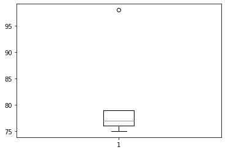

```python
plt.boxplot(y1)
```

```
{'whiskers': [<matplotlib.lines.Line2D at 0x7f6386868bb0>,
 'caps': [<matplotlib.lines.Line2D at 0x7f638687b310>,
 'boxes': [<matplotlib.lines.Line2D at 0x7f6386868820>],
 'medians': [<matplotlib.lines.Line2D at 0x7f638687ba30>],
 'fliers': [<matplotlib.lines.Line2D at 0x7f638687bdc0>],
 'means': []}
```

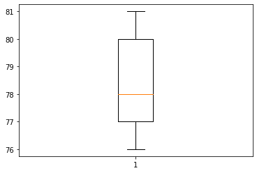

```python
plt.boxplot(y2)
```

- B반의 boxplot

`-` 따로따로 그리는것은 별로 좋지않은 시각화 방법같다. (한눈에 보이지 않음, y축의 scale도 다름)

`-` 아래와 같이 개선해보자.

```
{'whiskers': [<matplotlib.lines.Line2D at 0x7f638685ca60>,
 'caps': [<matplotlib.lines.Line2D at 0x7f63867eb1c0>,
 'boxes': [<matplotlib.lines.Line2D at 0x7f638685c6d0>,
 'medians': [<matplotlib.lines.Line2D at 0x7f63867eb8e0>,
 'fliers': [<matplotlib.lines.Line2D at 0x7f63867ebc70>,
 'means': []}
```

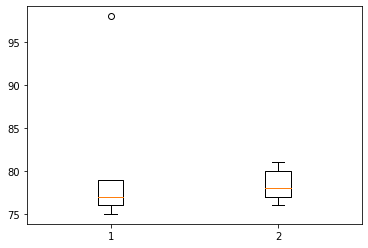

```python
plt.boxplot([y1,y2])
```

`-` 미적인 요소가 아쉽긴 하지만 이정도는 괜찮다.

#### 박스플랏이란? (통계학과)

`-` ref: https://towardsdatascience.com/understanding-boxplots-5e2df7bcbd51

- github: https://github.com/mGalarnyk/Python_Tutorials/blob/master/Statistics/boxplot/box_plot.ipynb

`-` 아래의 그림을 보면서 이해하자.

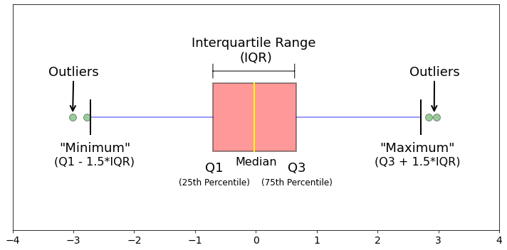

```python
np.random.seed(916170)

# connection path is here: https://stackoverflow.com/questions/6146290/plotting-a-line-over-several-graphs
mu, sigma = 0, 1 # mean and standard deviation
s = np.random.normal(mu, sigma, 1000)

fig, axes = plt.subplots(nrows = 1, ncols = 1, figsize=(10, 5))

# rectangular box plot
bplot = axes.boxplot(s,
                vert=False,
                patch_artist=True,
                showfliers=True, # This would show outliers (the remaining .7% of the data)
                positions = [0],
                boxprops = dict(linestyle='--', linewidth=2, color='Black', facecolor = 'red', alpha = .4),
                medianprops = dict(linestyle='-', linewidth=2, color='Yellow'),
                whiskerprops = dict(linestyle='-', linewidth=2, color='Blue', alpha = .4),
                capprops = dict(linestyle='-', linewidth=2, color='Black'),
                flierprops = dict(marker='o', markerfacecolor='green', markersize=10,
                  linestyle='none', alpha = .4),
                widths = .3,
                zorder = 1)

axes.set_xlim(-4, 4)
plt.xticks(fontsize = 14)

axes.set_yticks([])
axes.annotate(r'',
            xy=(-.73, .205), xycoords='data',
            xytext=(.66, .205), textcoords='data',
            arrowprops=dict(arrowstyle="|-|",
                            connectionstyle="arc3")
            );

axes.text(0, .25, "Interquartile Range \n(IQR)",  horizontalalignment='center', fontsize=18)
axes.text(0, -.21, r"Median", horizontalalignment='center', fontsize=16);
axes.text(2.65, -.15, "\"Maximum\"", horizontalalignment='center', fontsize=18);
axes.text(-2.65, -.15, "\"Minimum\"", horizontalalignment='center', fontsize=18);
axes.text(-.68, -.24, r"Q1", horizontalalignment='center', fontsize=18);
axes.text(-2.65, -.21, r"(Q1 - 1.5*IQR)", horizontalalignment='center', fontsize=16);
axes.text(.6745, -.24, r"Q3", horizontalalignment='center', fontsize=18);
axes.text(.6745, -.30, r"(75th Percentile)", horizontalalignment='center', fontsize=12);
axes.text(-.68, -.30, r"(25th Percentile)", horizontalalignment='center', fontsize=12);
axes.text(2.65, -.21, r"(Q3 + 1.5*IQR)", horizontalalignment='center', fontsize=16);

axes.annotate('Outliers', xy=(2.93,0.015), xytext=(2.52,0.20), fontsize = 18,
            arrowprops={'arrowstyle': '->', 'color': 'black', 'lw': 2},
            va='center');

axes.annotate('Outliers', xy=(-3.01,0.015), xytext=(-3.41,0.20), fontsize = 18,
            arrowprops={'arrowstyle': '->', 'color': 'black', 'lw': 2},
            va='center');

fig.tight_layout()
```

#### plotly (컴퓨터공학과)

```python
import plotly.express as px
from IPython.display import HTML
import pandas as pd
```

```python
A=pd.DataFrame({'y':y1,'x':['A']*len(y1)})
B=pd.DataFrame({'y':y2,'x':['B']*len(y2)})
df=pd.concat([A,B],ignore_index=True)
```

```python
df
```

|  | y | x |
| --- | --- | --- |
| 0 | 75 | A |
| 1 | 75 | A |
| 2 | 76 | A |
| 3 | 76 | A |
| 4 | 77 | A |
| 5 | 77 | A |
| 6 | 79 | A |
| 7 | 79 | A |
| 8 | 79 | A |
| 9 | 98 | A |
| 10 | 76 | B |
| 11 | 76 | B |
| 12 | 77 | B |
| 13 | 77 | B |
| 14 | 78 | B |
| 15 | 78 | B |
| 16 | 80 | B |
| 17 | 80 | B |
| 18 | 80 | B |
| 19 | 81 | B |

```python
fig=px.box(data_frame=df,x='x',y='y')
HTML(fig.to_html(include_plotlyjs='cdn',include_mathjax=False))
```

[interactive chart not shown]

### histogram

#### 히스토그램이란?

`-` X축이 변수의 구간, Y축은 그 구간에 포함된 빈도를 의미함

`-` 예를들면 아래와 같은것

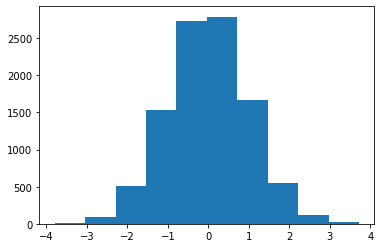

```python
plt.hist(np.random.normal(loc=0,scale=1,size=10000))
```

#### 전북고예제

`-` 중심경향값, 집중경항치 (Measure of central tendency): 분포의 중심성을 나타내기 위한 값, 예시로는 평균 중앙값등이 있음.

- https://en.wikipedia.org/wiki/Central_tendency

`-` "평균이 항상 좋은 중심경향값은 아니다"라는 사실은 이해했음.

`-` 하지만 특수한 상황을 가정하면 평균이 좋은 중심경향값임.

```python
np.random.seed(43052)
y1=np.random.normal(loc=0,scale=1,size=10000) # 전북고 A반의 통계학 성적이라 생각하자.
y2=np.random.normal(loc=0.5,scale=1,size=10000) # 전북고 B반의 통계학 성적이라 생각하자.
```

```python
np.mean(y1), np.mean(y2)
```

```
(-0.011790879905079434, 0.4979147460611458)
```

```python
(np.mean(y2)-np.mean(y1)).round(3)
```

```
0.51
```

```
{'whiskers': [<matplotlib.lines.Line2D at 0x7f6375dcd700>,
 'caps': [<matplotlib.lines.Line2D at 0x7f6375dcde50>,
 'boxes': [<matplotlib.lines.Line2D at 0x7f6375dcd4c0>,
 'medians': [<matplotlib.lines.Line2D at 0x7f6375ddb5b0>,
 'fliers': [<matplotlib.lines.Line2D at 0x7f6375ddb940>,
 'means': []}
```

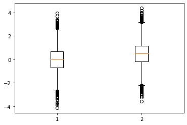

```python
plt.boxplot([y1,y2])
```

- 분포의 모양은 거의 비슷하다.
- 이런상황에서는 $B반의 성적 \approx A반의 성적+0.51$ 라고 주장해도 큰 무리가 없을 정도

`-` 정규분포를 가정하면 앞선예제와 같은 모양이 잘 안나옴.

`-` 그런데 정규분포인것은 어떻게 아는가? $\to$ 히스토그램을 그려봐서 종모양이 나오는지 살펴보자.

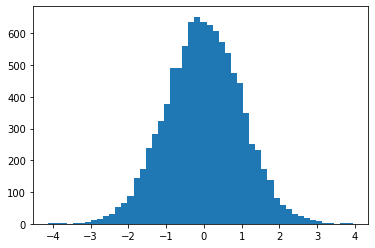

```python
plt.hist(y1,bins=50)
```

```python
plt.hist?
```

[output not shown]

[output cut: 155 more lines]

[output not shown]

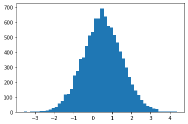

```python
plt.hist(y2,bins=50)
```

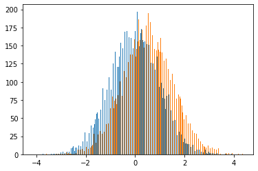

```python
plt.hist([y1,y2],bins=200)
```

#### seaborn

```python
A=pd.DataFrame({'y':y1,'x':['A']*len(y1)})
B=pd.DataFrame({'y':y2,'x':['B']*len(y2)})
df=pd.concat([A,B],ignore_index=True)
```

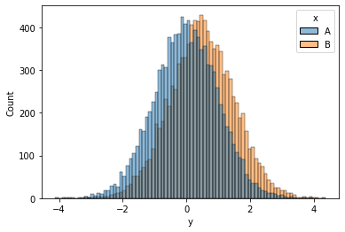

```python
sns.histplot(df,x='y',hue='x')
```

#### plotnine

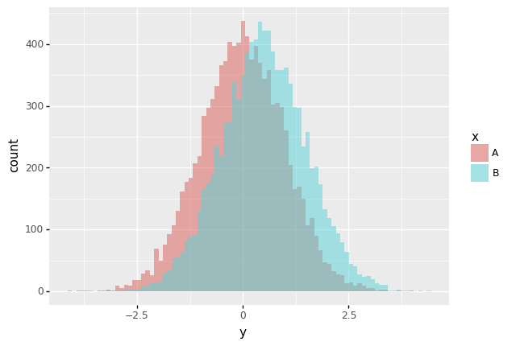

```python
from plotnine import *
ggplot(df)+geom_histogram(aes(x='y',fill='x'),position='identity',alpha=0.5)
```

#### plotly

`-` 인터렉티브 그래프를 위하여 plotly 갤러리 구경

```python
import plotly.figure_factory as ff
fig = ff.create_distplot([y1,y2], ['A','B'])
HTML(fig.to_html(include_plotlyjs='cdn',include_mathjax=False))
```

[interactive chart not shown]

`-` bin_size 변경

```python
fig = ff.create_distplot([y1,y2], ['A','B'], bin_size=.1)
HTML(fig.to_html(include_plotlyjs='cdn',include_mathjax=False))
```

[interactive chart not shown]

`-` 밑에 분포그램 없애기

```python
fig = ff.create_distplot([y1,y2], ['A','B'], bin_size=.1,show_rug=False)
HTML(fig.to_html(include_plotlyjs='cdn',include_mathjax=False))
```

[interactive chart not shown]

#### Histogram equalization

`-` ref: https://docs.opencv.org/4.5.0/d5/daf/tutorial_py_histogram_equalization.html

```python
import numpy as np
import cv2 as cv
from matplotlib import pyplot as plt
img = cv.imread('2021-09-05-Unequalized_Hawkes_Bay_NZ.jpeg',0)
```

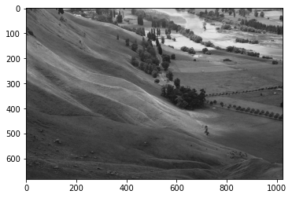

```python
plt.imshow(img,cmap='gray')
```

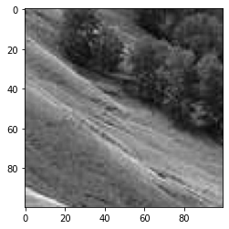

```python
plt.imshow(img[200:300,400:500],cmap='gray')
```

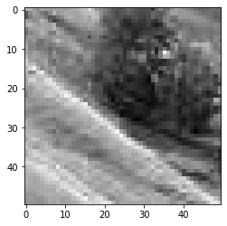

```python
plt.imshow(img[200:250,400:450],cmap='gray')
```

```python
df=pd.DataFrame(img)
df.iloc[200:250,400:450].style.set_properties(**{'font-size':'10pt'}).background_gradient('gray')
```

|  | 400 | 401 | 402 | 403 | 404 | 405 | 406 | 407 | 408 | 409 | 410 | 411 | 412 | 413 | 414 | 415 | 416 | 417 | 418 | 419 | 420 | 421 | 422 | 423 | 424 | 425 | 426 | 427 | 428 | … |
| --- | --- | --- | --- | --- | --- | --- | --- | --- | --- | --- | --- | --- | --- | --- | --- | --- | --- | --- | --- | --- | --- | --- | --- | --- | --- | --- | --- | --- | --- | --- |
| 200 | 155 | 155 | 151 | 149 | 152 | 152 | 151 | 152 | 152 | 152 | 152 | 153 | 154 | 155 | 157 | 158 | 164 | 157 | 150 | 148 | 146 | 143 | 139 | 138 | 138 | 140 | 142 | 140 | 138 | … |
| 201 | 139 | 148 | 152 | 149 | 145 | 142 | 147 | 156 | 150 | 152 | 154 | 154 | 153 | 153 | 155 | 157 | 158 | 159 | 155 | 149 | 144 | 142 | 139 | 136 | 138 | 139 | 140 | 139 | 137 | … |
| 202 | 138 | 145 | 149 | 149 | 149 | 144 | 138 | 139 | 144 | 148 | 153 | 155 | 153 | 152 | 153 | 155 | 153 | 158 | 157 | 147 | 140 | 140 | 139 | 136 | 137 | 135 | 135 | 137 | 137 | … |
| 203 | 152 | 151 | 148 | 150 | 156 | 152 | 141 | 134 | 137 | 141 | 147 | 151 | 152 | 152 | 153 | 154 | 152 | 155 | 153 | 144 | 137 | 138 | 139 | 139 | 134 | 130 | 130 | 134 | 135 | … |
| 204 | 155 | 156 | 153 | 151 | 153 | 153 | 152 | 155 | 141 | 141 | 142 | 144 | 147 | 149 | 151 | 151 | 153 | 152 | 149 | 145 | 140 | 137 | 138 | 140 | 133 | 130 | 129 | 131 | 132 | … |
| 205 | 145 | 151 | 152 | 153 | 154 | 152 | 152 | 156 | 151 | 147 | 141 | 139 | 141 | 144 | 147 | 148 | 151 | 149 | 149 | 148 | 145 | 138 | 135 | 136 | 134 | 133 | 131 | 130 | 130 | … |
| 206 | 143 | 147 | 149 | 151 | 155 | 152 | 146 | 145 | 154 | 151 | 146 | 143 | 142 | 143 | 144 | 145 | 144 | 146 | 147 | 146 | 142 | 138 | 136 | 134 | 133 | 135 | 134 | 130 | 129 | … |
| 207 | 148 | 151 | 150 | 149 | 151 | 150 | 149 | 151 | 150 | 150 | 151 | 150 | 148 | 145 | 144 | 144 | 137 | 144 | 145 | 139 | 135 | 137 | 138 | 135 | 131 | 136 | 136 | 130 | 129 | … |
| 208 | 150 | 148 | 151 | 145 | 143 | 147 | 148 | 153 | 158 | 153 | 150 | 152 | 149 | 143 | 141 | 144 | 145 | 145 | 144 | 142 | 140 | 137 | 133 | 131 | 130 | 133 | 131 | 130 | 137 | … |
| 209 | 153 | 147 | 147 | 143 | 144 | 147 | 144 | 146 | 150 | 149 | 150 | 152 | 153 | 151 | 146 | 143 | 142 | 142 | 141 | 139 | 137 | 135 | 134 | 134 | 133 | 131 | 130 | 129 | 130 | … |
| 210 | 154 | 147 | 147 | 145 | 145 | 145 | 141 | 145 | 143 | 145 | 147 | 149 | 153 | 155 | 151 | 144 | 144 | 143 | 141 | 139 | 137 | 136 | 137 | 137 | 136 | 130 | 132 | 135 | 129 | … |
| 211 | 153 | 149 | 152 | 151 | 148 | 146 | 143 | 150 | 143 | 143 | 143 | 145 | 148 | 150 | 150 | 148 | 149 | 146 | 142 | 140 | 139 | 139 | 138 | 137 | 137 | 131 | 137 | 143 | 137 | … |
| 212 | 156 | 151 | 153 | 151 | 150 | 149 | 145 | 149 | 147 | 144 | 144 | 146 | 146 | 143 | 144 | 149 | 149 | 144 | 139 | 138 | 139 | 139 | 136 | 132 | 136 | 132 | 138 | 142 | 141 | … |
| 213 | 160 | 152 | 151 | 149 | 151 | 153 | 145 | 142 | 148 | 145 | 146 | 150 | 148 | 141 | 141 | 147 | 146 | 142 | 137 | 137 | 139 | 139 | 135 | 131 | 134 | 132 | 134 | 134 | 136 | … |
| 214 | 160 | 157 | 157 | 150 | 150 | 153 | 146 | 143 | 146 | 146 | 147 | 149 | 147 | 144 | 143 | 144 | 144 | 142 | 138 | 137 | 138 | 137 | 136 | 134 | 132 | 133 | 133 | 132 | 132 | … |
| 215 | 157 | 162 | 167 | 156 | 148 | 151 | 149 | 151 | 145 | 145 | 145 | 143 | 144 | 146 | 146 | 143 | 143 | 142 | 139 | 137 | 135 | 134 | 134 | 135 | 130 | 134 | 136 | 136 | 134 | … |
| 216 | 156 | 146 | 149 | 163 | 166 | 153 | 146 | 152 | 145 | 144 | 143 | 144 | 145 | 145 | 143 | 141 | 139 | 141 | 136 | 133 | 138 | 136 | 130 | 131 | 131 | 132 | 136 | 137 | 134 | … |
| 217 | 155 | 156 | 158 | 158 | 159 | 158 | 154 | 148 | 150 | 146 | 142 | 143 | 145 | 145 | 142 | 138 | 136 | 135 | 131 | 132 | 137 | 138 | 135 | 133 | 136 | 131 | 129 | 130 | 132 | … |
| 218 | 153 | 161 | 162 | 156 | 157 | 164 | 164 | 156 | 152 | 150 | 148 | 145 | 142 | 141 | 141 | 141 | 141 | 135 | 132 | 133 | 135 | 136 | 135 | 130 | 135 | 130 | 127 | 128 | 130 | … |
| 219 | 153 | 155 | 157 | 158 | 159 | 161 | 164 | 165 | 157 | 155 | 151 | 147 | 144 | 142 | 142 | 142 | 148 | 139 | 137 | 136 | 132 | 131 | 132 | 126 | 129 | 130 | 131 | 131 | 130 | … |
| 220 | 151 | 151 | 153 | 157 | 157 | 156 | 158 | 162 | 164 | 159 | 153 | 150 | 150 | 148 | 144 | 140 | 145 | 137 | 137 | 137 | 130 | 129 | 131 | 129 | 127 | 129 | 131 | 131 | 130 | … |
| 221 | 147 | 151 | 154 | 154 | 155 | 158 | 160 | 159 | 161 | 164 | 164 | 160 | 152 | 146 | 144 | 145 | 142 | 137 | 137 | 136 | 130 | 127 | 129 | 131 | 131 | 129 | 127 | 126 | 128 | … |
| 222 | 146 | 151 | 153 | 152 | 154 | 159 | 160 | 158 | 156 | 162 | 168 | 166 | 157 | 150 | 148 | 150 | 145 | 142 | 138 | 136 | 133 | 127 | 125 | 129 | 131 | 131 | 129 | 126 | 126 | … |
| 223 | 151 | 149 | 149 | 151 | 152 | 151 | 152 | 153 | 159 | 157 | 157 | 162 | 167 | 165 | 155 | 145 | 147 | 146 | 139 | 136 | 137 | 130 | 124 | 130 | 128 | 134 | 136 | 132 | 126 | … |
| 224 | 152 | 151 | 150 | 150 | 150 | 151 | 152 | 152 | 151 | 155 | 160 | 161 | 161 | 161 | 164 | 167 | 146 | 149 | 145 | 136 | 131 | 132 | 131 | 126 | 128 | 126 | 126 | 128 | 130 | … |
| 225 | 151 | 149 | 147 | 146 | 146 | 147 | 149 | 149 | 151 | 153 | 155 | 156 | 157 | 159 | 161 | 164 | 162 | 151 | 144 | 143 | 140 | 132 | 128 | 129 | 132 | 129 | 127 | 127 | 128 | … |
| 226 | 148 | 147 | 146 | 146 | 148 | 150 | 151 | 151 | 152 | 151 | 150 | 151 | 153 | 156 | 159 | 160 | 164 | 162 | 155 | 147 | 142 | 140 | 135 | 130 | 125 | 125 | 126 | 127 | 129 | … |
| 227 | 148 | 149 | 149 | 150 | 151 | 151 | 150 | 149 | 150 | 150 | 150 | 151 | 153 | 155 | 156 | 157 | 157 | 165 | 166 | 156 | 148 | 146 | 143 | 137 | 126 | 126 | 126 | 126 | 126 | … |
| 228 | 153 | 152 | 150 | 149 | 148 | 146 | 145 | 143 | 147 | 149 | 151 | 153 | 153 | 153 | 154 | 155 | 154 | 157 | 163 | 166 | 160 | 150 | 146 | 148 | 140 | 136 | 130 | 125 | 122 | … |
| 229 | 155 | 152 | 149 | 147 | 146 | 146 | 147 | 147 | 144 | 146 | 149 | 151 | 150 | 150 | 151 | 153 | 153 | 155 | 158 | 162 | 163 | 161 | 154 | 149 | 141 | 138 | 134 | 131 | 129 | … |
| 230 | 154 | 153 | 151 | 149 | 149 | 149 | 149 | 149 | 145 | 145 | 145 | 145 | 147 | 149 | 151 | 152 | 151 | 157 | 157 | 153 | 157 | 166 | 163 | 154 | 141 | 139 | 137 | 136 | 136 | … |
| 231 | 156 | 155 | 155 | 154 | 152 | 148 | 145 | 142 | 148 | 144 | 141 | 141 | 145 | 149 | 152 | 153 | 155 | 153 | 152 | 154 | 156 | 158 | 163 | 168 | 154 | 147 | 139 | 135 | 134 | … |
| 232 | 156 | 156 | 155 | 153 | 153 | 152 | 150 | 146 | 147 | 146 | 146 | 147 | 147 | 147 | 146 | 145 | 150 | 152 | 153 | 153 | 154 | 156 | 159 | 161 | 170 | 158 | 142 | 133 | 134 | … |
| 233 | 153 | 157 | 160 | 158 | 153 | 151 | 150 | 149 | 146 | 148 | 149 | 149 | 147 | 145 | 143 | 142 | 144 | 146 | 148 | 150 | 151 | 154 | 156 | 158 | 163 | 165 | 161 | 150 | 139 | … |
| 234 | 157 | 155 | 154 | 153 | 155 | 156 | 152 | 147 | 144 | 147 | 149 | 148 | 145 | 144 | 144 | 145 | 144 | 145 | 146 | 149 | 152 | 154 | 155 | 155 | 156 | 161 | 166 | 163 | 156 | … |
| 235 | 159 | 156 | 151 | 151 | 155 | 158 | 155 | 150 | 148 | 149 | 148 | 146 | 144 | 144 | 145 | 147 | 147 | 147 | 146 | 148 | 151 | 153 | 153 | 153 | 154 | 155 | 157 | 161 | 165 | … |
| 236 | 155 | 159 | 161 | 159 | 155 | 156 | 158 | 160 | 156 | 155 | 153 | 150 | 148 | 147 | 145 | 144 | 144 | 143 | 142 | 143 | 145 | 148 | 150 | 150 | 155 | 156 | 156 | 155 | 157 | … |
| 237 | 154 | 158 | 162 | 161 | 160 | 159 | 158 | 157 | 157 | 157 | 156 | 156 | 156 | 154 | 150 | 147 | 141 | 140 | 139 | 140 | 143 | 146 | 149 | 150 | 151 | 154 | 155 | 153 | 153 | … |
| 238 | 160 | 158 | 157 | 157 | 161 | 162 | 158 | 153 | 154 | 155 | 156 | 157 | 157 | 157 | 156 | 156 | 146 | 146 | 145 | 144 | 144 | 146 | 148 | 149 | 148 | 150 | 152 | 153 | 155 | … |
| 239 | 163 | 163 | 161 | 158 | 157 | 158 | 159 | 159 | 155 | 156 | 156 | 154 | 153 | 154 | 157 | 161 | 153 | 153 | 152 | 149 | 146 | 144 | 144 | 145 | 149 | 152 | 153 | 151 | 150 | … |
| 240 | 158 | 159 | 162 | 165 | 165 | 163 | 158 | 155 | 166 | 156 | 150 | 153 | 155 | 153 | 153 | 157 | 156 | 153 | 150 | 149 | 150 | 150 | 148 | 146 | 144 | 148 | 151 | 151 | 150 | … |
| 241 | 156 | 157 | 159 | 161 | 163 | 163 | 161 | 160 | 158 | 162 | 161 | 154 | 151 | 155 | 157 | 156 | 152 | 155 | 157 | 154 | 149 | 147 | 148 | 150 | 147 | 146 | 146 | 148 | 152 | … |
| 242 | 155 | 155 | 155 | 157 | 160 | 162 | 164 | 164 | 160 | 160 | 161 | 161 | 157 | 152 | 154 | 158 | 155 | 155 | 154 | 154 | 154 | 152 | 150 | 148 | 148 | 146 | 145 | 147 | 151 | … |
| 243 | 155 | 154 | 153 | 154 | 157 | 160 | 162 | 164 | 164 | 157 | 157 | 162 | 162 | 155 | 153 | 156 | 156 | 153 | 152 | 153 | 156 | 156 | 153 | 150 | 149 | 149 | 149 | 148 | 147 | … |
| 244 | 155 | 154 | 153 | 154 | 155 | 157 | 159 | 159 | 159 | 163 | 162 | 158 | 158 | 163 | 160 | 153 | 151 | 153 | 155 | 154 | 152 | 151 | 155 | 158 | 153 | 152 | 151 | 149 | 147 | … |
| 245 | 154 | 153 | 153 | 153 | 154 | 155 | 155 | 155 | 158 | 162 | 164 | 162 | 160 | 161 | 161 | 160 | 154 | 154 | 153 | 152 | 152 | 153 | 155 | 157 | 157 | 154 | 150 | 150 | 151 | … |
| 246 | 152 | 152 | 152 | 153 | 154 | 154 | 154 | 154 | 159 | 156 | 158 | 164 | 165 | 160 | 159 | 162 | 161 | 156 | 151 | 151 | 154 | 156 | 155 | 152 | 156 | 154 | 152 | 152 | 153 | … |
| 247 | 150 | 150 | 150 | 152 | 153 | 155 | 155 | 155 | 154 | 156 | 156 | 156 | 162 | 168 | 163 | 152 | 159 | 159 | 158 | 155 | 151 | 150 | 152 | 154 | 152 | 155 | 157 | 155 | 151 | … |
| 248 | 150 | 151 | 150 | 149 | 150 | 152 | 154 | 153 | 154 | 152 | 152 | 154 | 157 | 160 | 164 | 168 | 159 | 159 | 163 | 164 | 157 | 148 | 147 | 151 | 152 | 154 | 155 | 157 | 157 | … |
| 249 | 149 | 150 | 150 | 149 | 149 | 151 | 153 | 152 | 154 | 152 | 152 | 153 | 154 | 155 | 158 | 161 | 162 | 161 | 162 | 164 | 166 | 164 | 157 | 150 | 153 | 153 | 153 | 153 | 153 | … |

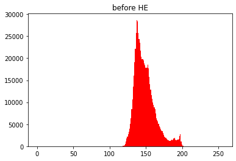

```python
plt.hist(img.flatten(),256,[0,256],color='r')
plt.title('before HE')
```

```python
img2=cv.equalizeHist(img)
```

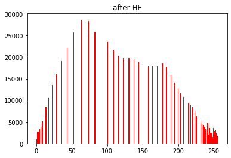

```python
plt.hist(img2.flatten(),256,[0,256],color='r')
plt.title('after HE')
```

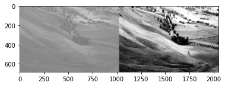

```python
_img=np.hstack((img,img2)) #stacking image side by side
plt.imshow(_img,cmap='gray')
```